# Analys av försäkringskostnader

Vilka faktorer driver kostnaderna?

Author

Jonas Lindström

Published

April 24, 2026

# 1 Introduktion

Syftet med denna rapport är att identifiera de främsta kostnadsdrivarna för försäkringsbolagets kunder samt undersöka om en regressionsmodell kan användas som beslutsstöd vid framtida prissättning. Genom att analysera historiska kunddata kan vi skapa en mer rättvis och riskbaserad prissättning.

# 2 Metod

Analysen bygger på datasetet insurance_costs.csv. Arbetet har genomförts i R (tidyverse) och strukturerats i separata skript för inläsning, städning, analys och visualisering. Minst en linjär regressionsmodell har byggts med charges som målvariabel.

# 3 Dataförståelse och städning

Datasetet består av 1100 observationer och 14 variabler, varav både numeriska (t.ex. ålder, BMI) och kategoriska (t.ex. rökning, region).

Under städningen identifierades saknade värden i variablerna bmi, exercise_level och annual_checkups. Dessa rader exkluderades då de utgjorde en liten andel av datasetet. Efter städning återstod 1031 observationer.

Kategoriska variabler trimmades och konverterades till gemener för att hantera stavningsinkonsekvenser, och därefter kodades som faktorer.

# 4 Ny variabel: BMI-grupp

För att tydliggöra riskgrupper skapades variabeln bmi_group med gränsvärdet 30 (WHO:s definition av fetma). Detta gör det möjligt att visualisera och diskutera hur fetma samverkar med andra riskfaktorer, särskilt rökning.

# 5 Beskrivande analys

### 5.0.1 Fördelning av kostnader och rökningens effekt

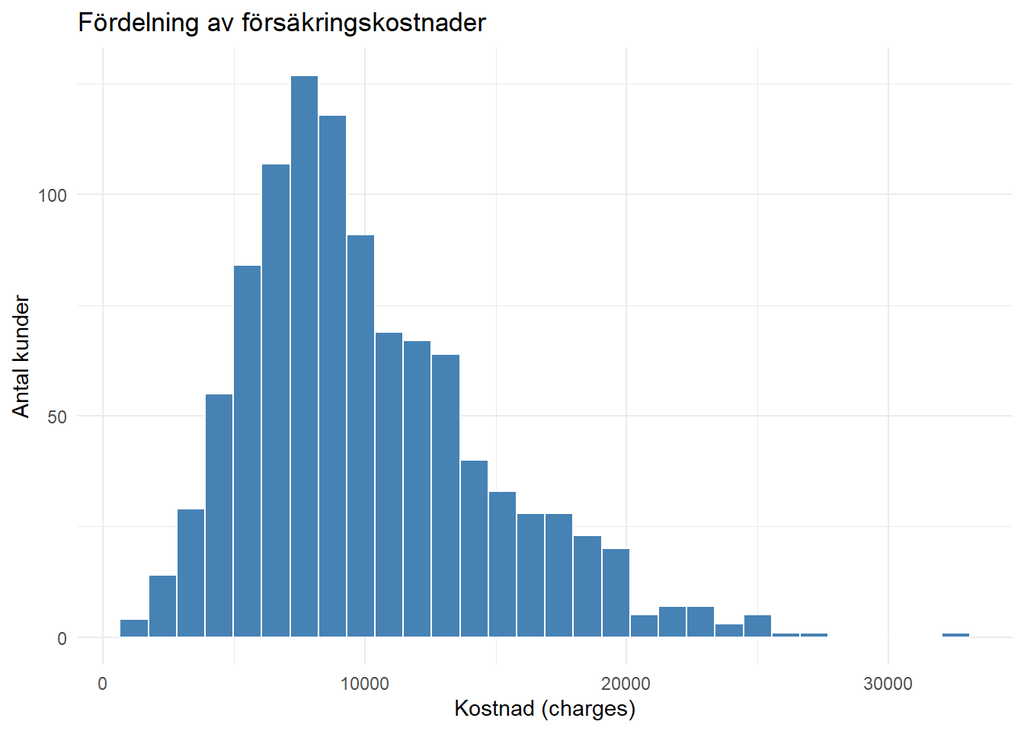

Fördelning av försäkringskostnader

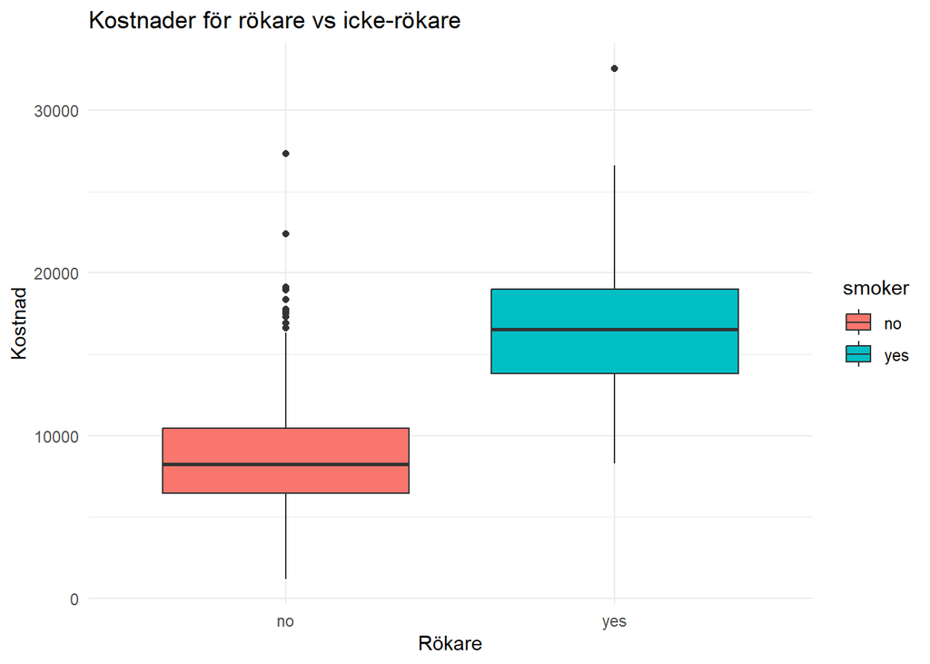

Kostnad för rökare vs icke-rökare

Histogrammet visar att försäkringskostnaderna är kraftigt högerskeva –majoriteten av kunderna har låga kostnader medan ett fåtal drar upp genomsnittet. Detta är viktigt att ha i åtanke vid regressionsanalysen, eftersom linjär regression fungerar bäst på normalfördelade data. Boxplotten visar en tydlig skillnad mellan rökare och icke-rökare: rökare har en betydligt högre mediankostnad samt större spridning.

### 5.0.2 Ålder och kostnad

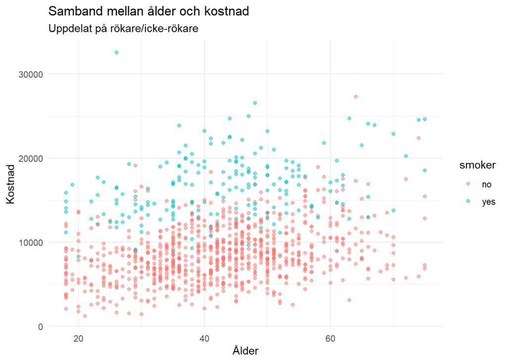

Samband mellan ålder och kostnad, uppdelat på rökare/icke-rökare

Kostnaden ökar linjärt med åldern för båda grupperna, men rökare ligger konsekvent på en högre kostnadsnivå. Detta tyder på att både ålder och rökning är oberoende kostnadsdrivare.

### 5.0.3 Interaktion mellan BMI och rökning

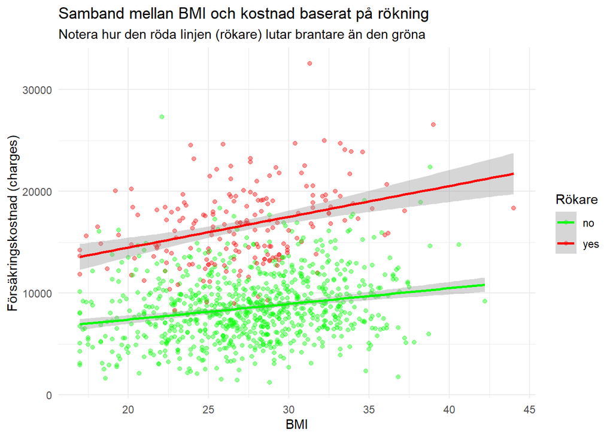

Interaktionseffekt: BMI och rökning

Figuren visar en stark interaktionseffekt: för icke-rökare (grön) har BMI liten påverkan på kostnaden, medan för rökare (röd) stiger kostnaden kraftigt med ökat BMI. Kombinationen rökning + högt BMI ger alltså oproportionerligt höga kostnader.

Sammanfattning: Rökning och BMI-status

| Rökare | BMI-grupp | Antal | Medelkostnad | Mediankostnad |
| --- | --- | --- | --- | --- |
| yes | Obese (30+) | 42 | 19579 | 18856 |
| yes | Non-Obese (<30) | 151 | 15825 | 15297 |
| no | Obese (30+) | 254 | 9575 | 9201 |
| no | Non-Obese (<30) | 584 | 8138 | 7964 |

Tabellen bekräftar mönstret: rökare med fetma har en medelkostnad på ca 19 600 kr, jämfört med icke-rökare utan fetma som ligger på ca 8 100 kr – en skillnad på över 140 %.

# 6 Regressionsanalys

För att kvantifiera sambanden byggdes två modeller:

- Enkel modell: charges ~ age + bmi + smoker
- Avancerad modell: charges ~ age + bmi * smoker + exercise_level + chronic_condition

Den avancerade modellen inkluderar en interaktionsterm (bmi * smoker) för att fånga upp det tydliga mönster vi såg i figur 4, samt kontrollerar för livsstils- och hälsofaktorer.

# 7 Resultat

Koefficienter från den enkla modellen

| term | estimate | std.error | statistic | p.value |
| --- | --- | --- | --- | --- |
| (Intercept) | 296.555 | 655.928 | 0.452 | 0.651 |
| age | 87.014 | 7.767 | 11.203 | 0.000 |
| bmi | 166.830 | 20.887 | 7.987 | 0.000 |
| smokeryes | 8083.136 | 246.205 | 32.831 | 0.000 |

Koefficienter från den avancerade modellen

| term | estimate | std.error | statistic | p.value |
| --- | --- | --- | --- | --- |
| (Intercept) | 428.932 | 578.428 | 0.742 | 0.459 |
| age | 73.848 | 6.248 | 11.819 | 0.000 |
| bmi | 122.629 | 18.461 | 6.643 | 0.000 |
| smokeryes | 2254.001 | 1237.577 | 1.821 | 0.069 |
| exercise_levellow | 1542.990 | 230.634 | 6.690 | 0.000 |
| exercise_levelmedium | 580.893 | 205.826 | 2.822 | 0.005 |
| chronic_conditionyes | 4135.528 | 181.368 | 22.802 | 0.000 |
| bmi:smokeryes | 197.276 | 44.859 | 4.398 | 0.000 |

Jämförelse av modellernas prestanda

| Modell | R² | Adj. R² | Sigma | AIC | BIC |
| --- | --- | --- | --- | --- | --- |
| Enkel modell | 0.554 | 0.553 | 3080.774 | 19495.76 | 19520.45 |
| Avancerad modell | 0.715 | 0.713 | 2468.766 | 19043.08 | 19087.52 |

# 8 Tolkning

Modellen uppnår en förklaringsgrad (Adjusted R²) på **71.3%**, vilket är en markant förbättring jämfört med den enklare modellen (Adj. R² = **55.3%**).

# 9 Slutsatser

Analysen visar att rökning, BMI och ålder är de tydligaste kostnadsdrivarna, och att kombinationen rökning + fetma + låg eller ingen träning ger en oproportionerligt hög riskprofil. För försäkringsbolaget innebär detta att en riskbaserad prissättning bör:

- Väga rökstatus tungt
- Beakta BMI särskilt för rökare (interaktionseffekt)
- Inkludera ålder och kroniska sjukdomar som justeringsvariabler
- Överväga incitament för livsstilsfaktorer, t.ex. rabatter för dokumenterad fysisk aktivitet

# 10 Begränsningar

- Högerskev fördelning: charges är inte normalfördelad. En log-transformation (log(charges)) skulle sannolikt förbättra modellen.
- Linjäritetsantagande: Linjär regression kan missa icke-linjära samband.
- Exkluderade observationer: Rader med saknade värden togs bort istället för att imputeras.
- Okända variabler: Faktorer som yrke, genetik och lokala prisnivåer saknas i datasetet.
- Kausalitet: Modellen visar samband, inte orsakssamband.
- Kronisk sjuk: Variabeln chronic_condition är binär (ja/nej), vilket är en kraftig förenkling av verkligheten. Som person med erfarenhet av kronisk sjukdom (MS) vet jag att vårdbehov och kostnader varierar enormt mellan olika diagnoser. Modellen missar nyanserna i hur olika sjukdomar påverkar individens ekonomi och livskvalitet.

# 11 Förbättringar

- Testa log(charges) som målvariabel
- Pröva icke-linjära modeller (t.ex. random forest, GAM)
- Validera modellen på ett separat test-set (t.ex. 80/20-split)
- Undersöka influential observations och residualer mer noggrant

# 12 Självreflektion

## 12.1 Etisk reflektion

Ur ett etiskt perspektiv är det problematiskt att beskatta kroniskt sjuka med högre premier. Till skillnad från rökning och träning är en kronisk sjukdom sällan ett självvalt livsstilsval. I ett system som det amerikanska (vilket datat liknar) riskerar sjuka individer att hamna i en ekonomisk utförsbacke, medan vi i Sverige har ett högkostnadsskydd som jämnar ut dessa skillnader. Detta är en viktig distinktion om modellen skulle implementeras i en svensk kontext.

## 12.2 Vad gjorde jag bra?

Jag strukturerade projektet i tydliga skript (load, prepare, analyze, visualize) och motiverade varje steg. Jag byggde två modeller – en enkel och en med interaktionsterm – och kunde tolka resultaten i kontext.

## 12.3 Vad var svårast?

Att tolka interaktionstermen i regressionen och att välja vilken nivå av detalj som skulle med i rapporten utan att bli för teknisk.

## 12.4 Betygsnivå:

Jag bedömer att min inlämning motsvarar VG eftersom jag:

- Genomfört alla steg i uppgiften
- Skapat minst 4 figurer/tabeller med tolkning
- Byggt två regressionsmodeller, inklusive en med interaktionsterm
- Motiverat variabelval och skapat en ny variabel (bmi_group)
- Diskuterat modellens styrkor, svagheter och förbättringar
- Strukturerat koden modulärt över flera skript